# Capitulo 4 - Estadistica 2

## 4.4 **Probabilidad Condicional**

Se conoce como probabilidad condicional, a la probabilidad de un evento que es influenciado por el acontecimiento de otro evento relacionado. Dado un evento $A$ con su probabilidad independiente $P(A)$, un evento $B$ efectuado y relacionado a $A$. Podemos denotar a la nueva probabilidad o probabilidad condicional como $P(A|B)$. La denotación indica que se esta considetando la probabilidad del evento $A$ dada la condicion de que $B$ ha ocurrido. Que puede ser leido como: "*la probailidad A dado B*".

La probabilidad conjunta se define como la probabilidad de la intersección de dos eventos, es decir, la probabilidad de que dos eventos ocurran a la par.

La Probabilidad de un evento $A$ en conjunto al evento $B$

$$ P(A\cap B) \space o \space P(B\cap A)$$

La probabilidad marginal se rerfiere a las probabilidades de un evento independiente de otros eventos con los que tengan relación. Además de que la suma de todas la probablidades conjuntas respecto a un evnto dado nos da como resultado la probabilidad marginal del evento dado.

**Ejercicio 1.** Para entender mejor los distintos conceptos de probabilidad, podemos plantearnos la siguiente situación:

Imaginemos que en la facultad de Ciencias Puras Y Naturales de la UMSA, se tenga un registro sobre los nuevos estudiantes registrados en las diferentes carreras de la facultad.  
La carrera de Informática es una carrera que cuenta con una cantidad considerable de estudiantes nuevos por año, a comparación de otras carreras de la facultad.  
En el año x se registro que ingresaron 4120 nuevos estudiantes en la carrera de informática, donde 3100 estudiantes eran varones y 1020 mujeres.  
Pero en las otras carreras se registraron 3580 nuevos estudiantes donde 1880 estudiantes eran varones y 1700 eran mujeres.

Consideremos los eventos: $ I =$ El evento en el que el estudiante estudiará la carrea de Informática

$ I^C = $El evento en el que el estudiante no estudiará la carrea de Informática

$ V =$ El evento en el que el estudiante es varón

$M =$ El evento en el que el estudiante es mujer

**Tabla 4.5** Tabla de Probabilidad Conjunta sobre estudiantes nuevos

| Eventos | Varón (V) | Mujer (M) | Total |
| --- | --- | --- | --- |
| Estudiarán Informática $(I)$ | 3100 | 1020 | 4120 |
| No Estudiarán Informática $(I^C)$ | 1880 | 1700 | 3580 |
| Total | 4980 | 2720 | 7700 |

Donde con ayuda de la tabla 4.5 obtenemos las diferentes probabildades conjuntas sobre un estudiante nuevo:

$P(V \cap I) = \frac{3100}{7700} = 0,40 $ , probabilidad de que el estudiante sea varón y estudie informática

$P(V \cap I^C) = \frac{1880}{7700} = 0,25 $ , probabilidad de que el estudiante sea varón y no estudie informática

$P(M \cap I) = \frac{1020}{7700} = 0,13 $ , probabilidad de que el estudiante sea mujer y estudie informática

$P(M \cap I^C) = \frac{1700}{7700} = 0,22 $ , probabilidad de que el estudiante sea mujer y no estudie informática

Con un análisis de la probabilidad condicional: Dado un evento $A$ con $P(A)$ y un evento $B$ ya ocurrido, conociendo la probabilidad del evento $A$ conjunto $B$ o $P(A\cap B)$,podemos calcular la probabilidad de un evento $A$ dado $B$:

Probabilidad Condicional

$$ P(A|B)=\frac{P(A\cap B)}{P(B)} $$

(4.7)

o en el caso de, la probabilidad de $B$ dado $A$:

$$ P(B|A)=\frac{P(A\cap B)}{P(A)} $$

(4.8)

Con el siguiente diagrama de Venn podemos tener una percepcion mas intuitiva sobre la conjuncion de eventos y la probabilidad de los mismos, y su cálculo:

**Figura 4.8** Probabilidad Condicional *P(A | B) = P(A $\cap$ B)/ P(B)*

```python
import matplotlib.pyplot as plt
from matplotlib_venn import venn2
# Datos de ejemplo
A = {1,2,3,4,5}
B = {4,5,6,7,8}
intersection = A.intersection(B)
color_a = 'lightgreen'
color_b = 'lightgreen'
venn_diagram = venn2([A,B], set_labels=('Evento A', 'Evento B'), set_colors=(color_a, color_b))

venn_diagram.get_label_by_id('10').set_text('P ( A )')
venn_diagram.get_label_by_id('01').set_text('P ( B )')
venn_diagram.get_label_by_id('11').set_text('P ( A∩B )')

plt.show()
```

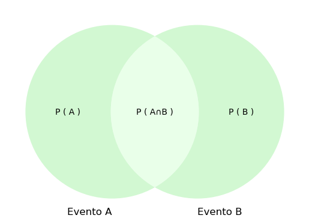

**Ejemplo:** Si seguimos tomando en cuenta la situacion planteada gracias a la tabla 4.5 y con ayuda de la fórmulas 4.7 y 4.8 podemos calcular algunas de las probabilidades condicionales:

$P(I|V) =\frac{\frac{3100}{7700}}{\frac{4980}{7700}} = \frac{3100}{4980} = 0,62 $ , probabilidad de que un estudiante varón estudie informática

$P(I|M) =\frac{\frac{1020}{7700}}{\frac{2720}{7700}} = \frac{1020}{2720} = 0,38 $ , probabilidad de que un estudiante mujer estudie informática

$P(I^C|V) =\frac{\frac{1880}{7700}}{\frac{4980}{7700}} = \frac{1880}{4980} = 0,38 $ , probabilidad de que un estudiante varón no estudie informática

$P(I^C|M) =\frac{\frac{1700}{7700}}{\frac{2720}{7700}} = \frac{1700}{2720} = 0,62 $ , probabilidad de que un estudiante mujer no estudie informática

$P(V|I) =\frac{\frac{3100}{7700}}{\frac{4120}{7700}} = \frac{3100}{4120} = 0,75 $ , probabilidad de que un estudiante de informática sea varon

$P(M|I) =\frac{\frac{1020}{7700}}{\frac{4120}{7700}} = \frac{1020}{4120} = 0,25 $ , probabilidad de que un estudiante de informática sea mujer

$P(V|I^C) =\frac{\frac{1880}{7700}}{\frac{3580}{7700}} =\frac{1880}{3580} = 0,53 $ , probabilidad de que un estudiante que no es de informática sea varon

$P(M|I^C) =\frac{\frac{1700}{7700}}{\frac{3580}{7700}} = \frac{1700}{3580} = 0,47 $ , probabilidad de que un estudiante que no es de informática sea mujer

Cabe recalcar equellas diferencias entre la preposicion verbal de las probabilidades respecto a las otras , es decir , no es lo mismo expresar "*la probabilidad de que un estudiante varón estudie informática*" y "*la probabilidad de que un estudiante sea varon y estudie informática*"

### **Eventos independientes**

EVENTOS INDEPENDIENTES

Dos eventos A Y B son independientes si:

$$ P(A|B)=P(A) $$

(4.9)

o

$$ P(B|A)=P(B) $$

(4.10 )

caso contrario, los eventos son dependientes.

### **Ley de la multiplicación**

Es utilizada para calcular la probabilidad de la intersección de dos eventos.  
Esta ley se apoya con el concepto de la probabilidad condicional.

LEY DE LA MULTPLICACIÓN

$$ P(A\cap B)=P(B)\cdot P(A|B) $$

(4.11)

o

$$ P(A\cap B)=P(A)\cdot P(B|A) $$

(4.12)

**EJEMPLO:** Si volvmos a tomar en cuenta la situacion planteada por la tabla 4.5 y usando las fórmulas 4.11 y 4.12 podemos calcular la probabilidades conjuntas:

$P(V\cap I) = {\frac{4120}{7700}}\cdot{\frac{3100}{4120}} = \frac{3100}{7700}= 0,40 $

$P(V\cap I) = {\frac{4980}{7700}}\cdot{\frac{3100}{4980}} = \frac{3100}{7700}= 0,40 $

$P(M\cap I) = {\frac{4120}{7700}}\cdot{\frac{1020}{4120}} = \frac{1020}{7700}= 0,13 $

$P(M\cap I) = {\frac{2720}{7700}}\cdot{\frac{1020}{2720}} = \frac{1020}{7700}= 0,13 $

$P(V\cap I^C) = {\frac{3580}{7700}}\cdot{\frac{1880}{3580}} = \frac{1880}{7700}= 0,25 $

$P(V\cap I^C) = {\frac{4980}{7700}}\cdot{\frac{1880}{4980}} = \frac{1880}{7700}= 0,25 $

$P(M\cap I^C) = {\frac{3580}{7700}}\cdot{\frac{1700}{3580}} = \frac{1700}{7700}=0,22 $

$P(M\cap I^C) = {\frac{2720}{7700}}\cdot{\frac{1700}{2720}} = \frac{1700}{7700}=0,22 $

Y comprobando los resultados nos damos cuentaque los calculos son correctos, aunque es de esperarse debido a que la ley de la multiplicación es una ecuacion despejada sobre la ecuacion de la probabilidad condicional.

También es importante indicar un caso especial sobre la ley de la multiplicación, que consiste en la indepedencia de los eventos involucrados entre sí, lo que indicaria que las probabilidades condicionales tendrian el valor de su probabilidad marginal, es decir $P(A|B) = P(A)$ o $P(B|A) = P(B)$, por lo tanto la ley de la multiplicación en este caso tendría el siguiente cambio.

LEY DE LA MULTIPLICACIÓN PARA EVENTOS INDEPENDIENTES

$$ P(A\cap B)=P(A)\cdot P(B) $$

(4.13)

## 4.5 **Teorema de bayes**

### **Definición**

El teorema de Bayes es una fórmula matemática que describe cómo se actualizan las probabilidades de una hipótesis en función de nueva evidencia.

En términos simples, el teorema de Bayes establece cómo se deben ajustar las probabilidades de eventos o hipótesis a la luz de una nueva . La forma general del teorema de Bayes se expresa como:

Fórmula general del teorema de Bayes

$$P(A|B) = \frac{P(B|A)*P(A)}{P(B)}$$

Donde: 1. $P(A|B)$ es la probabilidad de la hipótesis A dado que ha ocurrido el evento B. 2. $P(B|A)$ es la probabilidad del evento B dado que la hipótesis A es verdadera. 3. $P(A)$ es la probabilidad a priori de la hipótesis A, es decir, la probabilidad de A antes de tener en cuenta la evidencia B. 4. $P(B)$ es la probabilidad marginal del evento B, es decir, la probabilidad de que ocurra B.

El teorema de Bayes se aplica en una amplia variedad de campos, desde la inteligencia artificial y la estadística hasta la toma de decisiones y la medicina.

```python
from IPython.display import YouTubeVideo
print('Teorema de Bayes - Probabilidades - Ejercicios Resueltos')
ruta_video = YouTubeVideo('CP4ToX5Tyvw')
display(ruta_video)
```

```
Teorema de Bayes - Probabilidades - Ejercicios Resueltos
```

[video not shown]

```python
from IPython.display import YouTubeVideo
print('Introducción a la teoría de Bayes')
ruta_video = YouTubeVideo('bDfCURXoKkU')
display(ruta_video)
```

```
Introducción a la teoría de Bayes
```

[video not shown]

**Ejercicio 1.** Considere una tienda de barrio que recibe gaseosas de dos distribuidoras diferentes. Sea A1 el evento de que un paquete proviene de la distribuidora 1, y A2 el evento de que un paquete proiene de la distribuidora 2. En la actualidad, 65% de las partes adquiridas por la tienda de barrio son de la distribuidora 1 y el 35% restante son de la distribuidora 2. De ahí que si un paquete es seleccionado al azar, se le asignarían las probabilidades previas $P(A1)=0.65$ y $P(A2)=0.35$

|  | Refacciones en buen estado (porcentaje) | Refacciones en mal estado (porcentaje) |
| --- | --- | --- |
| Distribuidora 1 | 98 | 2 |
| Distribuidora 2 | 95 | 5 |

Si $G$ denota el evento de que una refacción está en buen estado y $B$ denota el evento de que una refacción está en mal estado, la información de la tabla anterior proporciona los valores de probabilidad condicional siguientes.

$$P(G|A_1)=0.98 P(B|A_1)=0.02$$ $$P(G|A_2)=0.95 P(B|A_2)=0.05$$

Partiendo de que $B$ denota el evento de que la refaccion se encuentra en mal estado, se buscan las probabilidades posteriores $P(A_1|B)$ y $P(A_2|B)$. A partir de la let de la probabilidad condicional sabemos que:

$$P(A_1|B)=\frac{P(A_1 \cap B)}{P(B)}(\star)$$

(4.14)

Si nos remitimos al arbol de probabilidades, obtenemos: $$P(A_1 \cap B)=P(A_1)P(B|A_1) (\alpha)$$ La probabilidad del resultado es: $$P(A_1 \cap G)=P(A_1)P(G|A_1)=0.6370$$ $$P(A_1 \cap B)=P(A_1)P(B|A_1)=0.0130$$ $$P(A_2 \cap G)=P(A_2)P(G|A_2)=0.3325$$ $$P(A_2 \cap B)=P(A_2)P(B|A_2)=0.0175$$ Para obtener $P(B)$ notemos que el evento $B$ puede ocurrir de dos maneras diferentes: $A_1\cap B$ $A_2$. Por lo tanto: $$P(B)=P(A_1\cap B)+P(A_2\cap B)$$ $$P(B)=P(A_1)P(B|A_1)+P(A_2)P(B|A_2) (\gamma)$$

Reemplazando $(\alpha)$ y $(\gamma)$ en $(\star)$ obtenemos: $$P(A_i|B)=\frac{P(A_i)P(B|A_i)}{P(A_1)P(B|A_1)+P(A_2)P(B|A_2)+...+P(A_n)P(B|A_n)}$$ Utilizando la formula anterior hallaremos los valores requeridos: $$P(A_1|B)=\frac{P(A_1)P(B|A_1)}{P(A_1)P(B|A_1)+P(A_2)P(B|A_2)}=0.4262$$

$$P(A_2|B)=\frac{P(A_2)P(B|A_2)}{P(A_1)P(B|A_1)+P(A_2)P(B|A_2)}=0.5738$$

```python
import numpy as np
import matplotlib.pyplot as plt
import pandas as pd
import scipy.stats as st

def AiIB(pai, pai2, b, b2):
    return (pai * b) / ((pai * b) + (pai2 * b2))

# Datos del ejercicio
pa1, pa2 = 0.65, 0.35
pg1, pg2 = 0.98, 0.95
pb1, pb2 = 0.02, 0.05

# Crear un DataFrame con los datos del ejercicio
df = pd.DataFrame({
    'pa': [pa1, pa2],
    'pg': [pg1, pg2],
    'pb': [pb1, pb2]
}, index=['A1', 'A2'])

# Calculamos las probabilidades de Ai ∩ Gi usando la regla del producto
p_ag = df['pa'] * df['pg']

# Calculamos las probabilidades de Ai ∩ Bi usando la regla del producto
p_ab = df['pa'] * df['pb']

# Calculamos las probabilidades de Ai | Bi usando la función AiIB
p_a_b = np.array([round(AiIB(pa1, pa2, pb1, pb2), 4), round(AiIB(pa2, pa1, pb2, pb1), 4)])

# Creamos una figura con tres subgráficos
fig, ax = plt.subplots(1, 3, figsize=(12, 4))

# Agregamos los datos obtenidos a nuestro DataFrame
df['p_ag'] = p_ag
df['p_ab'] = p_ab
df['p_a_b'] = p_a_b

# Graficamos las probabilidades de Ai ∩ Gi como un gráfico de barras con bordes negros
ax[0].bar(['A1 ∩ G', 'A2 ∩ G'], p_ag, color=['#5CCB5f', '#5CCB5f'], edgecolor='black')
ax[0].set_ylabel('Probabilidad')
ax[0].set_title('Probabilidades de Ai ∩ Gi')

# Graficamos las probabilidades de Ai ∩ Bi como un gráfico de barras con bordes negros
ax[1].bar(['A1 ∩ B', 'A2 ∩ B'], p_ab, color=['#5CCB5f', '#5CCB5f'], edgecolor='black')
ax[1].set_ylabel('Probabilidad')
ax[1].set_title('Probabilidades de Ai ∩ Bi')

# Graficamos las probabilidades de Ai | Bi como un gráfico de pastel con bordes negros
ax[2].pie(p_a_b, labels=['A1 | B', 'A2 | B'], colors=['#5ccb5f', '#98f84a'], autopct='%1.2f%%', wedgeprops=dict(edgecolor='black'))
ax[2].set_title('Probabilidades de Ai | Bi')

# Mostrar la figura
print('\nDatos que el ejercicio nos brinda y hallados:')
display(df)
plt.tight_layout(pad=2)
plt.show()
```

```
Datos que el ejercicio nos brinda y hallados:
```

|  | pa | pg | pb | p_ag | p_ab | p_a_b |
| --- | --- | --- | --- | --- | --- | --- |
| A1 | 0.65 | 0.98 | 0.02 | 0.6370 | 0.0130 | 0.4262 |
| A2 | 0.35 | 0.95 | 0.05 | 0.3325 | 0.0175 | 0.5738 |

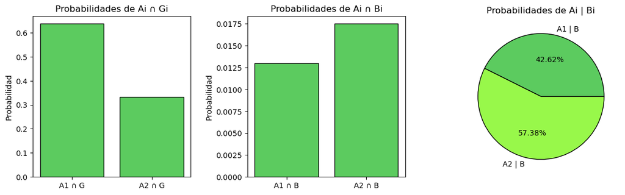

### **Método Tabular**

Este metodo es util para realizar calculos del teorema de Bayes. Para realizar la utilizacion de este metodo, debemos seguir una serie de pasos:

1. Crear 3 columnas, la primera para los eventos, la segunda para las probabilidades previas, la tercera para las probabilidades condicionales.
2. en la cuarta columna colocamos las probabilidades conjuntas y mostrar P(B)
3. Sumamos los valores de la columna 4, cada una debe estar dividida entre P(B)

Utilizando este metodo en el ejercicio anterior obtenemos:

**Tabla 4.7** Método tabular de los cálculos del teorema de Bayes para el problema de los dos proveedores

| Eventos | Probabilidades previas | Probabilidades condicionales | Probabilidades Conjuntas | Probabilidades Posteriores |
| --- | --- | --- | --- | --- |
| Distribuidora 1 | 0.65 | 0.02 | 0.0130 | 0.4262 |
| Distribuidora 2 | 0.35 | 0.05 | 0.0175 | 0.5738 |
|  | 1.00 |  | P(B)=0.0305 | 1.000 |

**Ejercicio 1.** Considere una libreria que recibe libros de tres editoriales diferentes. Sea A1 el evento de que un libro proviene de la editorial 1, A2 el evento de que un libro proviene de la editorial 2 y A3 el evento de que un libro proviene de la editorial 3. En la actualidad, 50% de los libros adquiridos por la libreria son de la editorial 1, 30% son de la editorial 2 y 20% son de la editorial 3. De ahí que si un libro es seleccionado al azar, se le asignarían las probabilidades previas $P(A1)=0.5$, $P(A2)=0.3$ y $P(A3)=0.2$.

|  | Libros con graficos (porcentaje) | Libros sin graficos (porcentaje) |
| --- | --- | --- |
| Editorial 1 | 99 | 1 |
| Editorial 2 | 96 | 4 |
| Editorial 3 | 92 | 8 |

Si $G$ denota el evento de que un libro tiene graficos y $F$ denota el evento de que un libro no tiene graficos, la información de la tabla anterior proporciona los valores de probabilidad condicional siguientes.

$$P(G|A_1)=0.99 P(F|A_1)=0.01$$ $$P(G|A_2)=0.96 P(F|A_2)=0.04$$ $$P(G|A_3)=0.92 P(F|A_3)=0.08$$

```python
import numpy as np
import scipy.stats as st
import matplotlib.pyplot as plt
import pandas as pd # Importar pandas

def AiIB(pai, pai2, pai3, b, b2, b3):
    return ((pai * b) + (pai2 * b2) + (pai3 * b3)) / ((pai * b) + (pai2 * b2) + (pai3 * b3) + (1 - pai - pai2 - pai3) * 0.1)

# Datos del ejercicio
pa = np.array([0.5, 0.3, 0.2]) # Estas son las probabilidades de elegir un paquete al azar de A1, A2 y A3
pg = np.array([0.99, 0.96, 0.92]) # Estas son las probabilidades de que el libro tenga graficos de A1, A2 y A3
pb = np.array([0.01, 0.04, 0.08]) # Estas son las probabilidades de que el libro no tenga graficos de A1, A2 y A3

# Definir pa3
pa3 = 1 - pa.sum()

# Crear un DataFrame con los datos del ejercicio
df = pd.DataFrame({'pa': pa, 'pg': pg, 'pb': pb}, index=['A1', 'A2', 'A3'])

# Calculamos las probabilidades de Ai ∩ Gi usando la regla del producto
p_ag = df['pa'] * df['pg']

# Calculamos las probabilidades de Ai ∩ Bi usando la regla del producto
p_ab = df['pa'] * df['pb']

# Calculamos las probabilidades de Ai | Bi usando la regla de Bayes
p_a_b = np.array([round(AiIB(pa[0], pa[1], pa[2], pb[0], pb[1], pb[2]), 4),
                  round(AiIB(pa[1], pa[0], pa[2], pb[1], pb[0], pb[2]), 4),
                  round(AiIB(pa[2], pa[0], pa[1], pb[2], pb[0], pb[1]), 4)])

# Creamos una figura con tres subgráficos
fig, ax = plt.subplots(1, 3, figsize=(12, 4))

# Agregamos los datos obtenidos a nuestro DataFrame
df['p_ag'] = p_ag
df['p_ab'] = p_ab
df['p_a_b'] = p_a_b

# Graficamos las probabilidades de Ai ∩ Gi como un gráfico de barras con bordes negros
ax[0].bar(['A1 ∩ G', 'A2 ∩ G', 'A3 ∩ G'], p_ag, color=['#5ccb5f', '#5ccb5f', '#5ccb5f'], edgecolor='black')
ax[0].set_ylabel('Probabilidad')
ax[0].set_title('Probabilidades de Ai ∩ Gi')

# Graficamos las probabilidades de Ai ∩ Bi como un gráfico de barras con bordes negros
ax[1].bar(['A1 ∩ B', 'A2 ∩ B', 'A3 ∩ B'], p_ab, color=['#5ccb5f', '#5ccb5f', '#5ccb5f'], edgecolor='black')
ax[1].set_ylabel('Probabilidad')
ax[1].set_title('Probabilidades de Ai ∩ Bi')

# Graficamos las probabilidades de Ai | Bi como un gráfico de pastel
ax[2].pie(p_a_b, labels=['A1 | B', 'A2 | B', 'A3 | B'], colors=['#5ccb5f', '#98f84a', '#e1ffaf'], autopct='%1.2f%%', wedgeprops=dict(edgecolor='black'))
ax[2].set_title('Probabilidades de Ai | Bi')

# Mostrar la figura
print('\nDatos que el ejercicio nos brinda y hallados:')
display(df)
print()
plt.tight_layout(pad=2)
plt.show()
```

```
Datos que el ejercicio nos brinda y hallados:
```

[output not shown]

[figure not shown]

Resolviendo por el metodo tabular:

[output not shown]